# Integración de dos lotes y cómo evaluarla

Sesión 09 · 17 de septiembre de 2026

## Objetivo

Diagnosticar un efecto de lote real, corregirlo con un método y **evaluar la corrección con métricas**, no solo mirando la gráfica.

**NotaCómo se reparte el trabajo**

**En clase no se corre nada.** Este documento ya trae los resultados con los datos de la práctica. Cada equipo, en su sala, lee las secciones **1 a 4** y la de **su método**, contesta las preguntas y pega en el tablero su figura y su fila de métricas. Las secciones 6 y 7 se discuten en plenaria.

**Después de la clase**, cada quien corre el código completo en el clúster. Si una celda tarda más de 5 minutos, avisa antes de seguir esperando.

## Antes de empezar

Todas las rutas de datos se declaran aquí y en ningún otro lugar del notebook. Si tu copia de los datos está en otro sitio, cambia solo esta celda.

```r
# Ruta al objeto de la práctica. La ruta del clúster se da en el chat de clase:
# escríbela entre las comillas del segundo argumento, por ejemplo
#   ruta_datos <- Sys.getenv("RUTA_S09", unset = "/ruta/que/te/dieron.rds")
# Sys.getenv() lee primero la variable de entorno RUTA_S09, que es la que usa el
# equipo docente para generar las versiones de clase. Si no hay ninguna de las
# dos, el notebook construye un objeto SINTÉTICO de respaldo.
ruta_datos <- Sys.getenv("RUTA_S09", unset = "")

# Carpeta donde se guardan las figuras que se pegan en el tablero.
dir_figuras <- "figuras-s09"
dir.create(dir_figuras, showWarnings = FALSE)
```

```r
library(SingleCellExperiment) # el contenedor de los datos
library(scater)               # componentes principales, UMAP y gráficas
library(scran)                # genes variables
library(batchelor)            # normalización entre lotes y fastMNN
library(bluster)              # agrupamiento por grafo de vecinos
library(cluster)              # silueta
library(ggplot2)              # guardar las figuras
library(patchwork)            # poner dos gráficas lado a lado
```

## 1. Los datos

### Qué son

Son **dos conjuntos públicos de 10x Genomics** de células mononucleares de sangre periférica (PBMC, por sus siglas en inglés: linfocitos T, linfocitos B, monocitos y células NK, *natural killer*):

| Lote | Conjunto | Química | Año |
| --- | --- | --- | --- |
| `pbmc3k` | PBMC 3k | v1 | 2016 |
| `pbmc10k` | PBMC 10k | v3 | 2018 |

PBMC 10k es el mismo conjunto que ya se trabajó en el módulo anterior.

**Qué es el lote aquí.** Son dos personas donantes distintas, procesadas en años distintos y con dos versiones de la química de 10x. Las tres cosas van juntas y con estos datos **no se pueden separar**: cuando hablemos del «efecto de lote», es la suma de las tres.

**AdvertenciaLo que se preparó antes de la clase**

- Cada célula lleva una **etiqueta gruesa** (T, B, monocito o NK), puesta con unos pocos marcadores clásicos. No es una anotación fina; esa se trabaja en otra clase.
- A uno de los dos lotes **se le quitó a propósito una población completa**. Descubrir cuál es parte de la práctica.

```r
if (nzchar(ruta_datos) && file.exists(ruta_datos)) {
  # --- Datos de clase ---------------------------------------------------------
  sce <- readRDS(ruta_datos)
  origen <- "objeto de clase (PBMC 3k + PBMC 10k)"
} else {
  # --- Respaldo sintético -----------------------------------------------------
  # Se usa solo si no hay ruta. Imita la estructura de los datos de clase:
  # dos lotes, cuatro tipos celulares, y un tipo que existe en un solo lote.
  set.seed(20260917)
  n_genes <- 1500
  n_por_tipo <- 200

  # Los perfiles de tipo celular se generan UNA vez y se usan en los dos lotes.
  # Generarlos por lote crearía un efecto de lote falso.
  base <- rgamma(n_genes, shape = 0.4, rate = 1)
  perfil <- function(ini, fin, factor = 25) {
    p <- base
    p[ini:fin] <- p[ini:fin] * factor
    p / sum(p)
  }
  perfil_T <- perfil(1, 150)
  perfiles <- list(
    T = perfil_T,
    B = perfil(151, 300),
    monocito = perfil(301, 450),
    # "NK" se parece a T: comparte casi todos sus marcadores y tiene 30 propios.
    NK = {
      p <- perfil_T
      p[451:480] <- p[451:480] * 12
      p / sum(p)
    }
  )

  # El efecto de lote es multiplicativo y distinto en cada gen.
  desplazamiento <- exp(rnorm(n_genes, mean = 0, sd = 1.2))

  generar <- function(tipo, n, lote) {
    p <- perfiles[[tipo]]
    if (lote == "lote2") p <- (p * desplazamiento) / sum(p * desplazamiento)
    totales <- rnbinom(n, mu = 3000, size = 8)
    vapply(totales, function(tt) rmultinom(1, max(tt, 1), p)[, 1], numeric(n_genes))
  }

  # En el lote 1 NO hay NK: es la población exclusiva del lote 2.
  diseno <- data.frame(
    tipo = c("T", "B", "monocito", "T", "B", "monocito", "NK"),
    lote = c("lote1", "lote1", "lote1", "lote2", "lote2", "lote2", "lote2")
  )
  cuentas <- do.call(cbind, Map(function(t, l) generar(t, n_por_tipo, l),
                                diseno$tipo, diseno$lote))
  rownames(cuentas) <- sprintf("Gen%04d", seq_len(n_genes))
  colnames(cuentas) <- sprintf("C%04d", seq_len(ncol(cuentas)))

  sce <- SingleCellExperiment(list(counts = as(cuentas, "dgCMatrix")))
  sce$tipo <- rep(diseno$tipo, each = n_por_tipo)
  sce$lote <- rep(diseno$lote, each = n_por_tipo)
  metadata(sce)$poblacion_exclusiva <- "NK"
  origen <- "objeto SINTETICO de respaldo"
}

cat("Trabajando con el", origen, "\n")
```

```
Trabajando con el objeto de clase (PBMC 3k + PBMC 10k)
```

```r
dim(sce)
```

```
[1] 30800  5204
```

**NotaSi ves `ó` en lugar de acentos**

Es el locale de R, no el notebook: cuando `LANG` no está en UTF-8, R escapa los caracteres acentuados **dentro de las tablas** que imprime. Se arregla con `export LANG=es_MX.UTF-8` antes de renderizar.

**Pregunta 1.1.** Antes de correr la siguiente celda: ¿qué esperas ver en una tabla de lote contra tipo celular?

```r
# Cuántas células hay de cada tipo en cada lote.
table(lote = sce$lote, tipo = sce$tipo)
```

```
         tipo
lote         B monocito   NK    T
  pbmc10k  233      826  382 1559
  pbmc3k     0      638  151 1415
```

**Pregunta 1.2.** ¿Hay algún tipo celular que exista en un solo lote? Anótalo: lo vas a necesitar en la sección 7.

## 2. Preparación común

```r
# 2.1 Normalización. multiBatchNorm() iguala la profundidad promedio entre
#     lotes antes de sacar logaritmos; sin eso, el lote con más lecturas
#     parece más "expresado" en todos los genes.
sce <- multiBatchNorm(sce, batch = sce$lote)

# 2.2 Genes variables. block = lote calcula la variabilidad DENTRO de cada lote
#     y luego la combina, para no elegir genes solo porque cambian de un lote
#     a otro.
dec <- modelGeneVar(sce, block = sce$lote)
hvg <- getTopHVGs(dec, n = 800)

# 2.3 Componentes principales (PCA, análisis de componentes principales) sin
#     ninguna corrección. Esta es la representación del control.
set.seed(100)
sce <- runPCA(sce, subset_row = hvg, ncomponents = 20)
pca <- reducedDim(sce, "PCA")
dim(pca)
```

```
[1] 5204   20
```

## 3. ¿Hay efecto de lote, y de qué tamaño?

Antes de corregir hay que saber si hay algo que corregir.

### 3.1 Diagnóstico visual

La gráfica usa UMAP (*Uniform Manifold Approximation and Projection*), una proyección a dos dimensiones que conserva bien los vecinos cercanos y **mal las distancias grandes**.

```r
# Colores fijos. Un color significa lo mismo en toda la figura: los dos lotes
# van en negro y magenta, que no se repiten entre los tipos celulares.
lotes <- sort(unique(sce$lote))
colores_lote <- setNames(c("#1A1A1A", "#D81B60"), lotes)
colores_tipo <- c(B = "#4E79A7", monocito = "#F28E2B", NK = "#59A14F", T = "#76B7B2")

# Orden AL AZAR para dibujar: si no, las células del último lote tapan a las
# del primero y la mezcla parece peor (o mejor) de lo que es.
set.seed(7)
orden_azar <- sample(ncol(sce))

# Dibuja una representación dos veces: coloreada por lote y por tipo celular.
# También guarda la figura en dir_figuras para pegarla en el tablero.
graficar <- function(sce, dimred, titulo, archivo) {
  nombre_umap <- paste0("UMAP_", dimred)
  set.seed(100)
  sce <- runUMAP(sce, dimred = dimred, name = nombre_umap)
  s <- sce[, orden_azar]
  p1 <- plotReducedDim(s, nombre_umap, colour_by = "lote", point_size = 0.5) +
    scale_colour_manual(values = colores_lote, name = "Lote") +
    ggtitle("Por lote")
  p2 <- plotReducedDim(s, nombre_umap, colour_by = "tipo", point_size = 0.5) +
    scale_colour_manual(values = colores_tipo, name = "Tipo celular") +
    ggtitle("Por tipo celular")
  figura <- (p1 | p2) + plot_annotation(title = titulo)
  ggsave(file.path(dir_figuras, archivo), figura, width = 10, height = 4.5, dpi = 150)
  print(figura)
  invisible(sce)
}
```

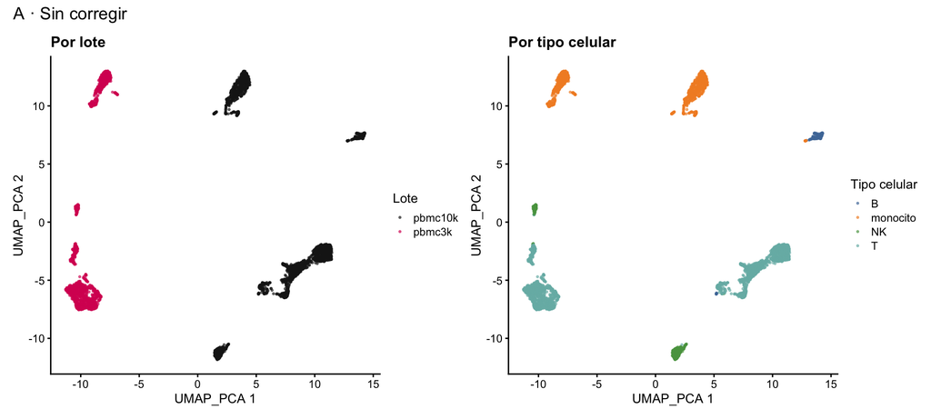

```r
graficar(sce, "PCA", "A · Sin corregir", "A-sin-corregir.png")
```

**Pregunta 3.1.** ¿Qué te dice la gráfica por lote? ¿Y la gráfica por tipo?

### 3.2 Diagnóstico con un número

¿Cuánto pesa el lote comparado con la biología? Para cada gen variable se mide qué fracción de su variación explica el lote (R², coeficiente de determinación: 0 = nada, 1 = todo) y qué fracción explica el tipo celular. Después se promedia.

```r
X <- as.matrix(logcounts(sce)[hvg, ])
r2_medio <- function(f) {
  f <- factor(f)
  mean(apply(X, 1, function(y) summary(lm(y ~ f))$r.squared))
}
c(lote = round(r2_medio(sce$lote), 3),
  tipo = round(r2_medio(sce$tipo), 3))
```

```
 lote  tipo
0.033 0.182
```

**Pregunta 3.2.** ¿Qué pesa más, el lote o el tipo celular? ¿Qué harías si el lote pesara más?

## 4. Las métricas, definidas antes de usarlas

Se decide qué se quiere de cada número **antes** de verlo. Si se decide después, siempre hay una métrica que da la razón.

### Dónde se calculan

Las tres métricas se calculan **sin el UMAP**. Se usan las componentes principales (en el control) o la representación corregida que devuelve cada método. El UMAP deforma las distancias para poder dibujar en dos dimensiones; por eso sirve para mirar, pero no para medir.

### Qué mide cada una

| Métrica | Pregunta que contesta | Escala | Qué valor se quiere tras corregir |
| --- | --- | --- | --- |
| **Entropía de mezcla** (*entropy of batch mixing*) | Entre las 30 vecinas más cercanas de cada célula, ¿hay células de los dos lotes? | de 0 (todas las vecinas son de su mismo lote) a 1 (vecinas de los dos lotes en la misma proporción) | que **suba** respecto al control |
| **Silueta por lote** | ¿El lote separa a las células en grupos? | de −1 a 1; 0 = los lotes están encimados | que **baje hacia 0** |
| **Silueta por tipo celular** | ¿El tipo celular separa a las células en grupos? | de −1 a 1; cerca de 1 = tipos bien separados | que **no baje** respecto al control |

**Entropía de mezcla, con sentido común.** Para cada célula se buscan sus 30 vecinas y se cuenta de qué lote es cada una. Si las 30 son de su mismo lote, esa célula vive en una zona de un solo lote: entropía 0. Si la mitad es de cada lote, la zona está mezclada: entropía 1. El número final es el promedio de todas las células.

**Silueta, con sentido común.** Para cada célula se calculan dos distancias:

- *a*: qué tan lejos está, en promedio, de las células con **su misma etiqueta**;
- *b*: qué tan lejos está de las células de la **otra etiqueta** más cercana.

La silueta es (*b* − *a*) / máx(*a*, *b*). Si *b* es mucho mayor que *a*, la célula está claramente en su grupo y la silueta se acerca a 1. Si *a* y *b* son parecidas, la etiqueta no separa nada y la silueta queda cerca de 0. Si es negativa, la célula está más cerca de la otra etiqueta que de la suya.

Por eso la misma función se usa dos veces con etiquetas distintas:

- con la etiqueta **lote**, una silueta alta es mala noticia: cada lote vive en su propia zona;
- con la etiqueta **tipo celular**, una silueta alta es buena noticia: los tipos se distinguen entre sí.

### No hay un valor «normal»

No existe un umbral universal («arriba de 0.5 está bien»). El valor depende de cuántas células hay de cada lote y de cada tipo. Por eso **cada método se compara contra el control sin corregir**, con los mismos datos.

Además, si una población existe en un solo lote, en su zona lo correcto es que **no** haya mezcla. Eso baja la entropía promedio aunque la corrección sea buena: con estos datos la entropía no puede llegar a 1.

```r
# ---------------------------------------------------------------------------
# Entropía de mezcla
#   emb  = matriz con una fila por célula y una columna por componente
#          (las componentes principales o la versión corregida de un método)
#   lote = el lote de cada célula, en el mismo orden que las filas de emb
#   k    = cuántas vecinas se revisan por célula
# ---------------------------------------------------------------------------
entropia_mezcla <- function(emb, lote, k = 30) {
  # findKNN() busca, para cada célula, las k células más cercanas en emb.
  # $index es una matriz: la fila i trae los números de las k vecinas de la
  # célula i.
  vecinos <- BiocNeighbors::findKNN(emb, k = k)$index
  niveles <- unique(lote)

  # apply(..., 1, ...) repite la función para cada fila, es decir, para cada
  # célula. idx son los números de sus vecinas.
  por_celula <- apply(vecinos, 1, function(idx) {
    # p = proporción de vecinas que hay de cada lote (por ejemplo 0.6 y 0.4).
    p <- table(factor(lote[idx], levels = niveles)) / length(idx)
    # Los lotes ausentes (proporción 0) se quitan: log(0) no existe.
    p <- p[p > 0]
    # Entropía: vale 0 si todas son de un lote y crece si hay de varios.
    # Se divide entre su máximo posible para que el resultado vaya de 0 a 1.
    -sum(p * log(p)) / log(length(niveles))
  })

  # El número final es el promedio de todas las células.
  mean(por_celula)
}

# ---------------------------------------------------------------------------
# Silueta promedio para una etiqueta (lote o tipo celular)
# ---------------------------------------------------------------------------
silueta <- function(emb, etiqueta) {
  # dist() calcula la distancia entre cada par de células.
  # silhouette() usa esas distancias para calcular a, b y la silueta de cada
  # célula; la columna "sil_width" trae ese valor.
  # silhouette() pide la etiqueta como número entero, por eso factor() y
  # as.integer().
  valores <- silhouette(as.integer(factor(etiqueta)), dist(emb))[, "sil_width"]
  # El número final es el promedio de todas las células.
  mean(valores)
}

# ---------------------------------------------------------------------------
# Una fila de la tabla comparativa: las tres métricas para una representación
# ---------------------------------------------------------------------------
evaluar <- function(emb, nombre) {
  data.frame(representacion = nombre,
             mezcla_lote = round(entropia_mezcla(emb, sce$lote), 3),
             silueta_lote = round(silueta(emb, sce$lote), 3),
             silueta_tipo = round(silueta(emb, sce$tipo), 3))
}

fila_A <- evaluar(pca, "A - sin corregir")
fila_A
```

```
    representacion mezcla_lote silueta_lote silueta_tipo
1 A - sin corregir       0.001        0.179        0.367
```

### Cómo leer esta fila

- `mezcla_lote` cerca de 0 → en el control, las vecinas de cada célula son casi siempre de su propio lote.
- `silueta_lote` claramente mayor que 0 → el lote, por sí solo, separa a las células en zonas.
- `silueta_tipo` → cuánto separa la biología. Es la referencia que **no** debe bajar después de corregir.

Hay algo que corregir cuando la mezcla es baja **y** la silueta por lote es positiva. Si la mezcla ya fuera alta y la silueta por lote cercana a 0, corregir solo movería células sin necesidad.

**Pregunta 4.1.** Con esta fila, ¿hay algo que corregir?

## 5. Un método por equipo

Cada equipo lee **su sección**, contesta sus preguntas y pega en el tablero su figura y su fila de métricas (para copiar la figura: clic derecho sobre ella).

| Equipo | Método | Qué supone |
| --- | --- | --- |
| A | Sin corregir | nada: es el **control** |
| B | `fastMNN` | que hay células **equivalentes** en los dos lotes |
| C | Harmony | que los grupos se pueden alinear poco a poco en el espacio de componentes |
| D | Anclas de Seurat | que hay puntos de correspondencia identificables entre lotes |

### 5A. Equipo A · el control

El equipo A ya tiene su figura (sección 3.1) y su fila (sección 4). Su tarea en la plenaria es recordarle al grupo **cómo se veían los datos antes de tocar nada**. Mientras los demás corren su método, prepara la sección 7 para el control.

### 5B. Equipo B · `fastMNN`

`fastMNN` (*fast Mutual Nearest Neighbors*, vecinos mutuos más cercanos): busca parejas de células que se eligen mutuamente como vecinas entre los dos lotes y usa esas parejas para calcular cuánto hay que mover cada lote.

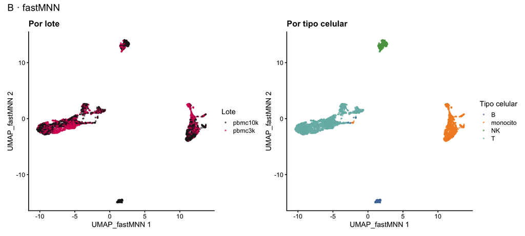

```r
set.seed(100)
mnn <- fastMNN(sce, batch = sce$lote, subset.row = hvg, d = 20)
# fastMNN devuelve las células en el mismo orden de entrada.
reducedDim(sce, "fastMNN") <- reducedDim(mnn, "corrected")

graficar(sce, "fastMNN", "B · fastMNN", "B-fastmnn.png")
```

```r
fila_B <- evaluar(reducedDim(sce, "fastMNN"), "B - fastMNN")
fila_B
```

```
  representacion mezcla_lote silueta_lote silueta_tipo
1    B - fastMNN       0.649        0.007        0.469
```

### 5C. Equipo C · Harmony

Harmony alterna dos pasos: agrupa las células y luego mueve cada grupo para que los lotes queden en la misma posición. Repite hasta que ya no hay nada que mover.

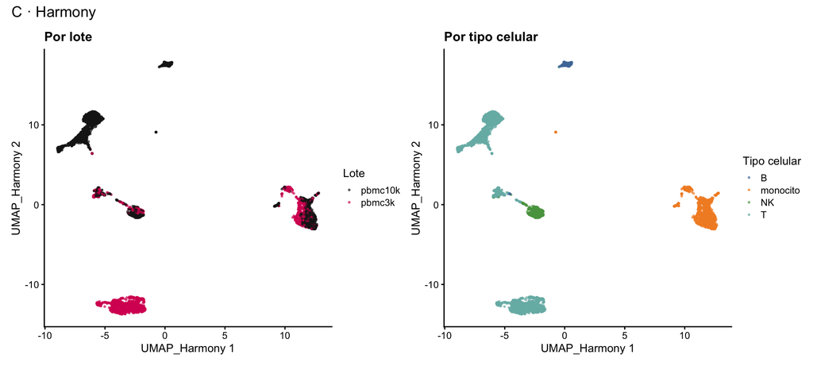

```r
library(harmony)
set.seed(100)
reducedDim(sce, "Harmony") <- RunHarmony(
  pca,                                      # parte del PCA sin corregir
  meta_data = data.frame(lote = sce$lote),  # la tabla con el lote de cada célula
  vars_use = "lote",                        # la columna que se corrige
  verbose = FALSE
)

graficar(sce, "Harmony", "C · Harmony", "C-harmony.png")
```

```r
fila_C <- evaluar(reducedDim(sce, "Harmony"), "C - Harmony")
fila_C
```

```
  representacion mezcla_lote silueta_lote silueta_tipo
1    C - Harmony       0.236          0.1        0.405
```

### 5D. Equipo D · anclas de Seurat

Seurat busca **anclas**: pares de células de lotes distintos que se parecen después de una proyección común (CCA, análisis de correlación canónica). Con esas anclas transforma un lote hacia el otro. Es la ruta que usan los módulos siguientes.

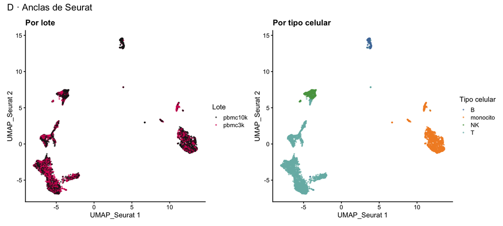

```r
library(Seurat)

# 1. Se pasa el objeto a Seurat, con el lote y el tipo como metadatos.
obj <- CreateSeuratObject(counts = counts(sce),
                          meta.data = as.data.frame(colData(sce)))

# 2. Seurat v5 integra "capas": una capa de cuentas por lote.
obj[["RNA"]] <- split(obj[["RNA"]], f = obj$lote)

# 3. El flujo de Seurat, que se vio en el módulo anterior.
obj <- NormalizeData(obj, verbose = FALSE)
obj <- FindVariableFeatures(obj, nfeatures = 800, verbose = FALSE)
obj <- ScaleData(obj, verbose = FALSE)
obj <- RunPCA(obj, npcs = 20, verbose = FALSE)

# 4. La integración por anclas. El resultado es una reducción nueva.
obj <- IntegrateLayers(obj, method = CCAIntegration,
                       orig.reduction = "pca",
                       new.reduction = "integrado_cca",
                       dims = 1:20, verbose = FALSE)

# 5. Se regresa al objeto de la práctica, en el mismo orden de células.
reducedDim(sce, "Seurat") <- Embeddings(obj, "integrado_cca")[colnames(sce), ]

graficar(sce, "Seurat", "D · Anclas de Seurat", "D-seurat.png")
```

```r
fila_D <- evaluar(reducedDim(sce, "Seurat"), "D - anclas de Seurat")
fila_D
```

```
        representacion mezcla_lote silueta_lote silueta_tipo
1 D - anclas de Seurat       0.827       -0.002        0.449
```

## 6. La comparación

Esta celda junta las filas que existan: en la versión de tu equipo verás el control y tu método. Las cuatro filas se juntan en el tablero.

```r
filas <- mget(c("fila_A", "fila_B", "fila_C", "fila_D"), ifnotfound = list(NULL))
do.call(rbind, filas)
```

```
             representacion mezcla_lote silueta_lote silueta_tipo
fila_A     A - sin corregir       0.001        0.179        0.367
fila_B          B - fastMNN       0.649        0.007        0.469
fila_C          C - Harmony       0.236        0.100        0.405
fila_D D - anclas de Seurat       0.827       -0.002        0.449
```

Preguntas para el tablero:

1. ¿Los lotes se mezclaron?
2. ¿Los **tipos celulares** siguen separados entre sí?
3. ¿Desapareció algún grupo que estaba en el control? → sección 7

### Cómo se contesta cada pregunta

Compara la fila de tu método contra la fila `A - sin corregir`:

| Pregunta | Dónde se mira | Qué indica que salió bien |
| --- | --- | --- |
| 1. ¿Se mezclaron los lotes? | `mezcla_lote` y `silueta_lote` | la mezcla **sube** y la silueta por lote **baja** hacia 0 |
| 2. ¿Siguen separados los tipos? | `silueta_tipo` | **no baja** respecto al control |
| 3. ¿Desapareció algún grupo? | la tabla de la sección 7 | la población exclusiva sigue en **su propio grupo** |

Las preguntas 1 y 2 se leen **juntas**. Un método que mezcla mucho los lotes pero baja la silueta por tipo no corrigió: borró biología. Un método que mezcla poco pero conserva los tipos se quedó corto, aunque no hizo daño.

## 7. ¿Sobrevivió la población que existe en un solo lote?

La tabla de la sección 6 contesta las preguntas 1 y 2. La 3 no: una métrica de mezcla alta no dice si se borró algo.

La celda siguiente agrupa las células en cada representación y busca el grupo donde quedó la mayoría de la población exclusiva. Después cuenta **cuántas células de otros tipos** quedaron en ese mismo grupo.

```r
exclusiva <- metadata(sce)$poblacion_exclusiva

destino <- function(emb, nombre) {
  set.seed(100)
  grupo <- clusterRows(emb, NNGraphParam(k = 20, cluster.fun = "louvain"))
  tabla <- table(grupo = grupo, tipo = sce$tipo)
  g <- names(which.max(tabla[, exclusiva]))       # el grupo con más exclusivas
  data.frame(representacion = nombre,
             grupos = length(unique(grupo)),
             exclusivas_en_su_grupo = tabla[g, exclusiva],
             exclusivas_total = sum(tabla[, exclusiva]),
             otras_en_ese_grupo = sum(tabla[g, ]) - tabla[g, exclusiva])
}

representaciones <- intersect(c("PCA", "fastMNN", "Harmony", "Seurat"),
                              reducedDimNames(sce))
do.call(rbind, lapply(representaciones,
                      function(r) destino(reducedDim(sce, r), r)))
```

```
  representacion grupos exclusivas_en_su_grupo exclusivas_total
1            PCA      9                    224              233
2        fastMNN      8                    224              233
3        Harmony      8                    223              233
4         Seurat      9                    228              233
  otras_en_ese_grupo
1                 13
2                  2
3                  6
4                 15
```

### Cómo leer esta tabla

| Columna | Qué es |
| --- | --- |
| `grupos` | cuántos grupos encontró el agrupamiento en esa representación |
| `exclusivas_en_su_grupo` | cuántas células de la población exclusiva quedaron en el grupo donde está la mayoría de ellas |
| `exclusivas_total` | cuántas células de la población exclusiva hay en total |
| `otras_en_ese_grupo` | cuántas células **de otros tipos** quedaron en ese mismo grupo |

La población sobrevivió si `exclusivas_en_su_grupo` está cerca de `exclusivas_total` **y** `otras_en_ese_grupo` es pequeño comparado con el control. Si `otras_en_ese_grupo` crece mucho, la corrección la mezcló con otro tipo celular, aunque la métrica de mezcla se vea bien.

**Pregunta 7.1.** En la representación de tu equipo, ¿la población exclusiva sigue siendo un grupo propio, o quedó mezclada con otro tipo celular?

**Pregunta 7.2.** Si quedó mezclada, ¿lo habrías notado mirando solo la columna `mezcla_lote`?

## Cómo decidir, paso a paso

Este diagrama resume la práctica. Los pasos 1 a 3 se contestan **antes** de corregir; el paso 4, comparando cada método contra el control sin corregir.

[figure not shown]

Diagrama de flujo para decidir si corregir el efecto de lote. Uno: si cada lote tiene una sola condición, no se corrige y se reporta la limitación. Dos: si no hay efecto de lote, no se corrige. Tres: si hay tipos celulares en un solo lote, se vigila esa población. Cuatro: se corrige con dos o tres métodos y se revisa que la mezcla suba, la silueta por tipo no baje y los marcadores sigan intactos; si ninguno sirve, se prueban parámetros o no se corrige. Cinco: lo corregido se usa para agrupar y visualizar, y la expresión diferencial se hace con cuentas y el lote en el modelo.

Lo menos obvio:

- la mezcla no llega a 1 si los lotes no tienen los mismos tipos celulares, y eso no es un fallo;
- el UMAP no decide: deciden las métricas;
- si un grupo del control desaparece, puede ser sobrecorrección o un artefacto del lote, y hay que investigarlo.

## Lo que te llevas

- Antes de corregir, mide **cuánto** pesa el lote frente a la biología.
- Decide qué quieres de cada métrica **antes** de calcularla.
- Una métrica de mezcla alta solo dice que los lotes se mezclaron. No dice si se conservó la biología.
- La pregunta «¿desapareció algún grupo que estaba en el control?» se contesta con una tabla, no con la gráfica.
- La representación corregida se usa para agrupar y visualizar. La expresión diferencial se hace sobre las cuentas, con el lote como covariable.

## Para pensar

Corregiste el efecto de lote de un estudio con cuatro donantes por condición —bien diseñado, sin confusión entre lote y condición— y las métricas de mezcla quedan excelentes. Al agrupar, una población que en el control sin corregir aparecía como grupo propio ya no está: sus células quedaron repartidas entre dos grupos vecinos.

Podría ser sobrecorrección, o podría ser que ese grupo del control fuera un artefacto del efecto de lote que la corrección disolvió correctamente. Las métricas de mezcla no distinguen entre las dos cosas y el UMAP tampoco.

¿Qué evidencia —de los datos, del diseño o de fuera del experimento— te permitiría decidir cuál de las dos ocurrió?